# Homework 3 - Task 3

Carmen Galaz-García

11/5/2020

# 1. Size comparisons between purple and red urchins

## Exploratory data visualization

The following graphs compare the distribution of urchin diameters (in cm) for purple urchin (*Strongylocentrotus purpuratus*) and red urchin (*Mesocentrotus franciscanus*) observed at 5 sites along the Santa Barbara coast.

### Histograms

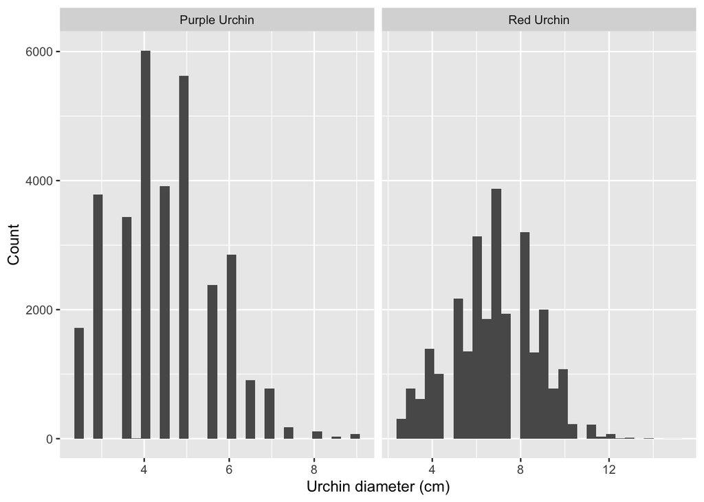

```r
ggplot(data = urchins, aes(x=size)) +   # select data and variable
  geom_histogram()+                     # do histogram
  facet_wrap(~common_name, scales = "free_x")+ # facet according to common_name and choose each x-axis length individually
  labs(x="Urchin diameter (cm)", y ="Count")   # update labels
```

### Boxplots

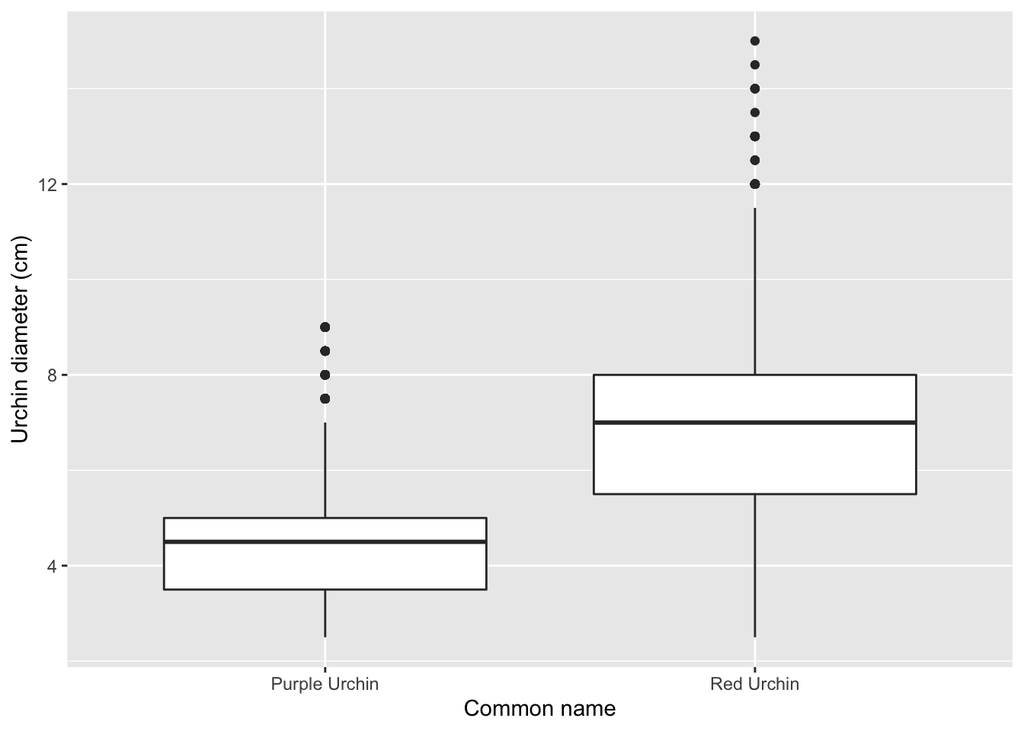

```r
ggplot(data=urchins, aes(x=common_name, y=size))+ # select data and variables
  geom_boxplot()+        # do boxplot
  labs( x="Common name", # update labels
        y="Urchin diameter (cm)")
```

## Descriptive statistics table

The table below contains the following statistics for purple and red urchins (ignoring site as a variable): mean, median, standard deviation, and sample size.

```r
urchins_stats <- urchins %>%           # copy all urchins data
  group_by(common_name) %>%            # analyze each group separately
  summarize(mean_size = mean(size),    # for each group calculate: size mean
            meadian_size=median(size),      # size median
            sd_size = sd(size),             # size standard deviation
            n =n())                         # number of individuals

# create table using kable
urchins_stats %>% kable( col.names = c("Common name",
                                       "Mean diameter (cm)",
                                       "Median size (cm)",
                                       "Standard deviation (cm)",
                                       "Sample size (n)" )
                         ) %>%
   kable_styling(full_width = FALSE)
```

| Common name | Mean diameter (cm) | Median size (cm) | Standard deviation (cm) | Sample size (n) |
| --- | --- | --- | --- | --- |
| Purple Urchin | 4.469797 | 4.5 | 1.175264 | 31805 |
| Red Urchin | 6.776489 | 7.0 | 1.891343 | 27408 |

### Analysis

We can see in the histogram for purple urchins that their size is slightly positively skewed. In their boxplot we can further see that there is a long tail with possible outliers which have big diameter.

For red urchins we can see there is a bit of a tail to the right but otherwise the distribution looks quite normal. This is also apparent in the boxplot showing more outliers with big diameter but otherwise a fairly symmetric box and whiskers.

We can see too that on average red urchins have a diameter (6.776489-4.469797)/4.469797* 100=51.6% bigger than that of a purple urchin. The absolute differences between the standard deviations of both populations is 0.7 cm, with red urchins presenting a greater variability, which is (1.891343-1.175264)/1.175264* 100 = 60.9% of that of purple urchins.

# 2. Exploring purple urchin counts

### Wrangling data

Using a piped sequence, we create a subset of the urchins data which only includes observations for purple urchins, has dates in class “Date”, has a column wich only contains the year of the observation and adds a column with the full name of the observation site.

```r
purple_urchins <- urchins %>%                   # assign dataset
  filter(common_name == "Purple Urchin") %>%    # select rows corresponding to purple urchins
  mutate(Year = year(mdy(date))) %>%            # create Year column
  mutate(site_full = case_when( site == "NAPL" ~ "Naples Reef",          # create column with complete names
                                site == "AQUE" ~ "Arroyo Quemado Reef",
                                site == "CARP" ~ "Carpinteria Reef",
                                site == "MOHK" ~ "Mohawk Reed",
                                site == "IVEE" ~ "Isla Vista Reef"))
```

### Summary table

The table below shows the total number of purple urchins observed by site and year.

```r
purples_summary <- purple_urchins %>%  # starting with purple_urchins data
  count(site_full, Year)               # count # individuals in each site in a given year

# create table
purples_summary %>% kable(col.names = c("Site", "Year", "Sample size (n)")) %>%
  kable_styling(full_width = FALSE)
```

| Site | Year | Sample size (n) |
| --- | --- | --- |
| Arroyo Quemado Reef | 2008 | 67 |
| Arroyo Quemado Reef | 2009 | 926 |
| Arroyo Quemado Reef | 2010 | 921 |
| Arroyo Quemado Reef | 2011 | 887 |
| Arroyo Quemado Reef | 2012 | 764 |
| Arroyo Quemado Reef | 2013 | 434 |
| Arroyo Quemado Reef | 2014 | 410 |
| Arroyo Quemado Reef | 2015 | 400 |
| Arroyo Quemado Reef | 2016 | 342 |
| Arroyo Quemado Reef | 2017 | 406 |
| Arroyo Quemado Reef | 2018 | 408 |
| Arroyo Quemado Reef | 2019 | 404 |
| Arroyo Quemado Reef | 2020 | 98 |
| Carpinteria Reef | 2008 | 265 |
| Carpinteria Reef | 2009 | 1315 |
| Carpinteria Reef | 2010 | 930 |
| Carpinteria Reef | 2011 | 1118 |
| Carpinteria Reef | 2012 | 743 |
| Carpinteria Reef | 2013 | 400 |
| Carpinteria Reef | 2014 | 415 |
| Carpinteria Reef | 2015 | 430 |
| Carpinteria Reef | 2016 | 423 |
| Carpinteria Reef | 2017 | 404 |
| Carpinteria Reef | 2018 | 474 |
| Carpinteria Reef | 2019 | 466 |
| Carpinteria Reef | 2020 | 130 |
| Isla Vista Reef | 2012 | 797 |
| Isla Vista Reef | 2013 | 370 |
| Isla Vista Reef | 2014 | 436 |
| Isla Vista Reef | 2015 | 402 |
| Isla Vista Reef | 2016 | 372 |
| Isla Vista Reef | 2017 | 362 |
| Isla Vista Reef | 2018 | 416 |
| Isla Vista Reef | 2019 | 299 |
| Isla Vista Reef | 2020 | 100 |
| Mohawk Reed | 2008 | 294 |
| Mohawk Reed | 2009 | 1344 |
| Mohawk Reed | 2010 | 923 |
| Mohawk Reed | 2011 | 958 |
| Mohawk Reed | 2012 | 856 |
| Mohawk Reed | 2013 | 399 |
| Mohawk Reed | 2014 | 440 |
| Mohawk Reed | 2015 | 418 |
| Mohawk Reed | 2016 | 402 |
| Mohawk Reed | 2017 | 434 |
| Mohawk Reed | 2018 | 459 |
| Mohawk Reed | 2019 | 369 |
| Mohawk Reed | 2020 | 134 |
| Naples Reef | 2008 | 246 |
| Naples Reef | 2009 | 1064 |
| Naples Reef | 2010 | 942 |
| Naples Reef | 2011 | 883 |
| Naples Reef | 2012 | 738 |
| Naples Reef | 2013 | 357 |
| Naples Reef | 2014 | 368 |
| Naples Reef | 2015 | 430 |
| Naples Reef | 2016 | 384 |
| Naples Reef | 2017 | 393 |
| Naples Reef | 2018 | 462 |
| Naples Reef | 2019 | 474 |
| Naples Reef | 2020 | 100 |

### Exploratory graph

In the following graphs we see the change in the counts of purple urchins recorded at each site over time for the years included in the study.

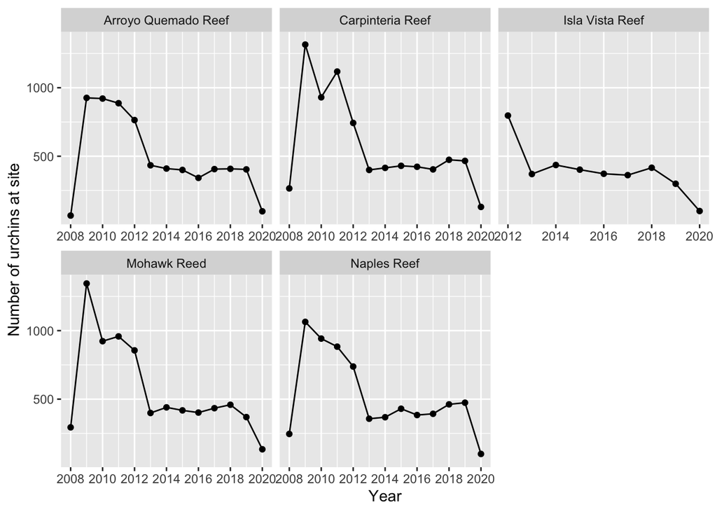

```r
ggplot( data = purples_summary, aes(x=Year, y=n))+        # select data and variables
  geom_line() +                                           # line+point to join the dots
  geom_point() +
  facet_wrap(~site_full, scales = "free_x") +             # facet by site
  scale_x_continuous(breaks=2*(1004:1010))  +             # update x-axis ticks
  labs(y="Number of urchins at site")
```